# How Economic Development Reshapes Health Risk Across the Life Cycle

How two distinct risk indicators evolve with economic development

Author

Sabrina Vitali

Published

April 10, 2026

## 1 Introduction

This report explores how countries undergo economic development and how the dominant health risk shifts across the life course.

The distribution of health risk across different stages of life changes with the level of development.

The analysis highlights how development reshapes when and why risk occurs, from the neonatal period to adolescence.

The report takes into consideration two key dimensions:

1. EARLY-LIFE RISK, proxied by neonatal mortality
2. BEHAVIOURAL RISK, associated with alcohol consumption

Using UNICEF indicators and contextual metadata, the report asks a broader question: *does development reduce health risk, or does it transform it?*

It is evident that the two indicators do not capture the same type of risk. At first glance, early-life risk appears directly linked to mortality, while behavioural risk may seem less immediate and therefore less comparable. However, this analysis shows that the difference is not in magnitude, but in **nature**: the two indicators reflect distinct dimensions of risk that emerge at different stages of the life cycle.

GDP is used as a proxy for development to understand how economic growth influences health risks across the life course.

The analysis focuses mostly on 2016 as a snapshot year to compare how health risks are distributed across different levels of GDP.

## 2 Data Preparation

Before building the visualisations, the datasets were carefully cleaned and aligned to ensure consistency across indicators, countries, time.

The preparation process involved several key steps:

- **Selection of relevant variables**, focusing only on the indicators required for the analysis
- **Renaming and standardisation** of variables to improve clarity and comparability across datasets
- **Integration of the two indicators** into a unified analytical structure
- **Merging with GDP-related classifications**, allowing each observation to be linked to a level of economic development

This process was essential to ensure that all visualisations are based on a coherent and reproducible data structure.

It also enables a consistent comparison between the two indicators, both individually in relation to GDP and jointly to better understand how the structure of risk evolves with economic development.

### 2.1 A global perspective on early-life risk

The two maps provide a snapshot of how early-life risk is distributed across countries in 2016 and 2023.

At first glance, the pattern may appear counterintuitive: countries with higher levels of GDP often show a greater relative contribution of neonatal mortality (within the first 28 days of life) to total under-five mortality.

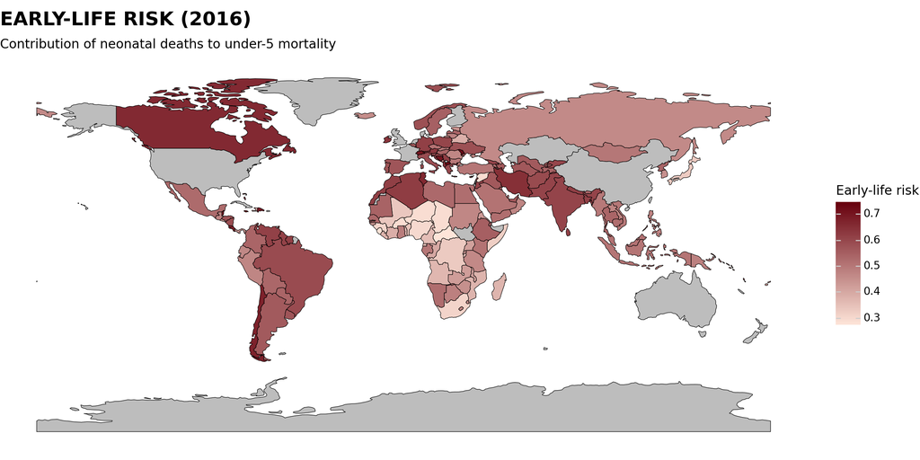

Geography of early-life risk in 2016.

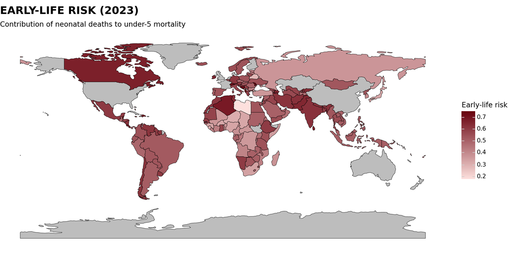

Geography of early-life risk in 2023.

Seven years later, the overall pattern remains consistent, although the intensity of the red tones is more pronounced, reflecting a higher concentration of neonatal mortality within the first 28 days of life.

### 2.2 Why does early-life risk increase with development?

This does not imply that countries with higher levels of GDP face worse health conditions. Instead, it reflects a structural transformation in the causes of mortality.

In low-income settings, deaths are more likely to occur after the neonatal period, often driven by preventable conditions such as infections, malnutrition and limited access to healthcare.

As countries undergo economic development, these causes decline significantly. What remains is a higher concentration of deaths in the neonatal phase, which is more closely linked to biological factors and the quality of advanced medical care.

In this sense, a higher share of early-life risk becomes an indirect signal of stronger health systems and higher levels of economic development.

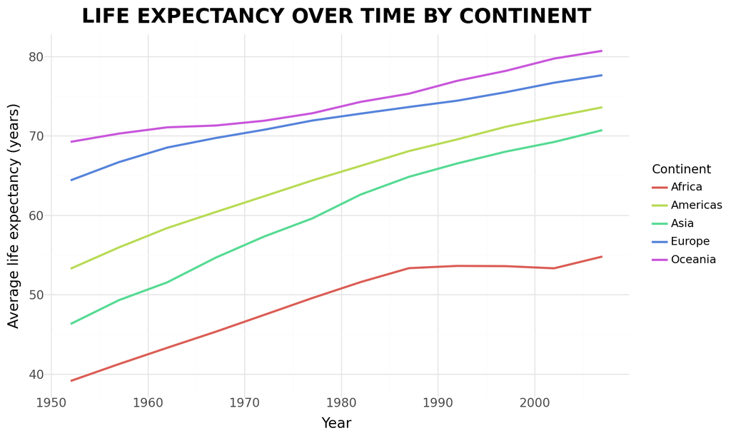

Average life expectancy over time by continent (Gapminder).

The continental trends are consistent with the distribution of economic development. Europe and Oceania, which represent the most developed regions, consistently show the highest levels of life expectancy, followed by the Americas. Asia occupies an intermediate position, while Africa remains at the lowest levels.

This pattern reinforces the idea that higher development is associated with longer life expectancy and a different structure of health risk across the life cycle.

### 2.3 How does this pattern evolve over time?

To better understand whether this relationship is persistent, we examine how early-life risk evolves across different levels of GDP over time.

This suggests that the shift toward early-life risk is not temporary, but a structural feature of economic development.

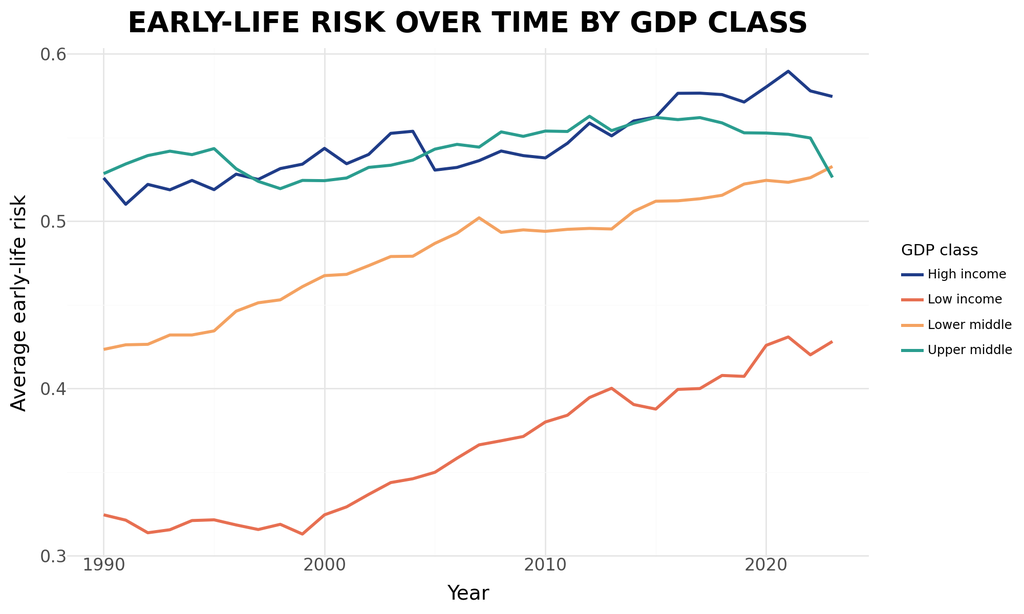

Early-life risk over time by GDP class.

Economic development does not eliminate risk — it reshapes it, concentrating mortality in earlier stages of life.

## 3 From Early-Life Risk to Behavioural Risk

After the early-life phase, the nature of risk changes.

While neonatal mortality reflects biological constraints and the quality of healthcare systems, adolescence introduces a different type of risk — one that is increasingly shaped by behaviour, lifestyle and social environment.

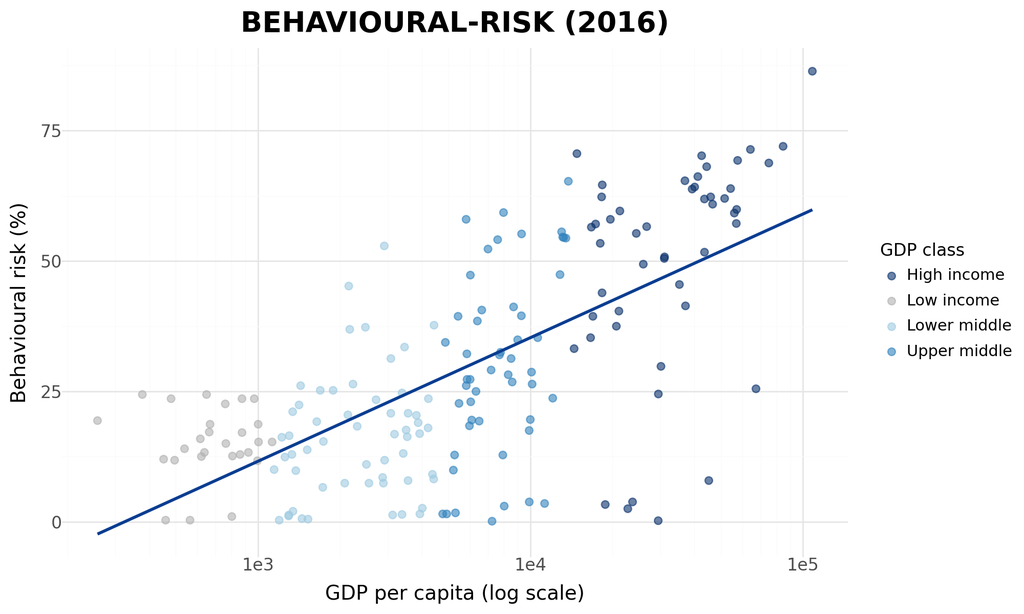

Relationship between GDP per capita and behavioural risk by income level (2016).

### 3.1 Alcohol Consumption and economic development

The scatterplot reveals a clear pattern: countries with higher levels of GDP per capita tend to exhibit higher levels of adolescent behavioural risk.

This does not imply that countries with higher GDP are “less healthy”. Rather, it indicates that risk takes a different form. As survival improves and basic health threats decline, new risks emerge, often linked to lifestyle choices such as alcohol consumption.

In this phase, economic development expands opportunities, exposure and autonomy, particularly among younger populations, increasing the likelihood of engaging in risky behaviours.

## 4 Is Risk Reduced or Redistributed?

The comparison between early-life risk and behavioural risk highlights a fundamental shift in the structure of health risk.

- In countries with lower levels of GDP, risk is primarily concentrated in survival-related conditions during early life.
- In countries with higher levels of GDP, risk progressively shifts toward behavioural factors during adolescence.

**Important**

As countries develop, risk extends itself according to the perceived level of safety within a country, which is indirectly related to their GDP and, consequently, to their structural development, including both urbanization and exposure to well-organized healthcare infrastructures. In more developed contexts, this creates a dual effect: on one hand, better healthcare systems lead to a higher concentration of neonatal mortality, as deaths become less related to preventable conditions and more linked to structural and biological factors; on the other hand, increased safety and stability reduce the perceived danger of everyday life, making individuals, especially in urban environments, more willing to expose themselves to new forms of risk.

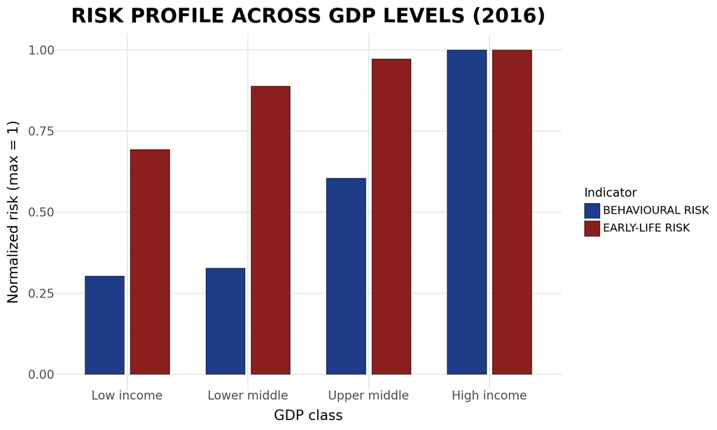

Normalized comparison of early-life and behavioural risk across GDP classes (2016).

### 4.1 A normalized comparison

By normalizing both indicators, we can directly compare how risk is distributed across different levels of GDP.

- Early-life risk remains relatively high across all countries, reflecting structural constraints that are harder to eliminate even at higher levels of development.
- Behavioural risk increases sharply with GDP, becoming more prominent in high-GDP settings.

**Note**

A key implication of this report is that public health progress should not be interpreted as the **end of risk**, but as a **shift in where risk is located across the life cycle**.

## 5 Key findings

1. Early-Life Risk is higher in countries with higher levels of development, and this should be interpreted positively, as it indicates a structural and medical limit that cannot be significantly reduced through further improvements in healthcare systems. It represents a type of risk that is almost irreducible.
2. The type of risk during the life cycle shifts from survival-related risk to Behavioural Risk, and the urbanization of a country, and therefore its level of GDP, actively influences the stimuli perceived by adolescents. Adolescents in more urbanized and developed countries are therefore more likely to engage in alcohol consumption, increasing behavioural risk during adolescence.

Overall, the analysis suggests that economic development does not simply reduce risk, but changes how risk is distributed across the life course. In more developed countries, some risks that are less immediate, such as risky behaviours during adolescence, may receive less attention in the short term but can become significant over time.

In contrast, in less developed countries, where early-life mortality risk is already high, populations and systems tend to avoid additional risks, as everyday life is already characterized by higher baseline danger. This suggests that differences in risk behaviour are not only a consequence of development, but also a form of adaptation to the surrounding risk environment.

### 5.2 Final Insight

Health risk is not a fixed quantity, it evolves with development.

From early-life survival challenges to behavioural risks in adolescence, the life cycle of risk mirrors the broader process of economic and social transformation.

## 6 Reproducibility

### 6.1 Code

The full code used for data preparation, analysis and visualisation is available on GitHub:

View the notebook

### 6.2 Data

[Dataset 1 - Neonatal deaths as a percentage of under-five deaths](https://github.com/sabrinavitali/economic-development-health-risk/blob/main/unicef_indicator_1.csv)

[Dataset 2 - Percentage of adolescents (aged 15-19 years) who had at least one alcoholic drink at any time during the last 12 months](https://github.com/sabrinavitali/economic-development-health-risk/blob/main/unicef_indicator_2.csv)

[Dataset 3 - UNICEF metadata](https://github.com/sabrinavitali/economic-development-health-risk/blob/main/unicef_metadata.csv)